# P1 : Test a Perceptual Phenomenon

### 1. What is our independent variable? What is our dependent variable?

**Independent Variable** : Type of words (Congruent or Incongruent)

**Dependent Variable** : Time taken by participants to read the words

### 2. What is an appropriate set of hypotheses for this task? What kind of statistical test do you expect to perform? Justify your choices.

**Hypotheses** :

Null Hypotheses : There is no significant difference between population means of times of Congruent and Incongruent groups.

Alterantive Hypotheses : The is a significant difference between population means of times of Congruent and Incongruent groups.

$$H_0 : \mu_C - \mu_I = 0 $$$$H_A : \mu_C - \mu_I != 0 $$

Where: $$ H_0 = Null Hypotheses \\ H_A = Alternate Hypotheses \\ \mu_C = Congruent Mean \\ \mu_I = Incongruent Mean $$

Here we are talking about population means of both Congruent and Incongruent groups. By taking the means of population groups, we can compare these easily. But it is very difficult to take test results of all people in the world. That's why we take a sample test results and make inference about the population means.

To verify that the difference is not just simply because of the variance in data, we will perform a dependent paired sample two tailed t-test with alpha level of 0.05. This is because the two samples are dependent and tested under same conditions. We are using t-test here because we are making inferences about unknown population parameters using sample parameters. We are using two tailed test because we don't know whether the resultant value will be either on left side or right side of population mean. So in a brief, we are using relatively small sample size(smaller than 30), we are assuming that the difference sample distribution is normal and both samples are dependent and tester under same conditions, we can use dependent two tailed t-test.

### 3. Report some descriptive statistics regarding this dataset. Include at least one measure of central tendency and at least one measure of variability.

**Descriptive Statistics**:

1. Congruent Mean: 14.051125
2. Incongruent Mean: 22.0159166667
3. Congruent Variance: 12.66902907
4. Incongruent Variance: 23.01175704
5. Mean of differences : -7.96479
6. Standard deviation of differences : 4.86482691

### 4. Provide one or two visualizations that show the distribution of the sample data. Write one or two sentences noting what you observe about the plot or plots

```python
%matplotlib inline
import pandas as pd
import matplotlib.pyplot as plt
import seaborn as sns
stroop = pd.read_csv("stroopdata.csv")
stroop.head()
```

|  | Congruent | Incongruent |
| --- | --- | --- |
| 0 | 12.079 | 19.278 |
| 1 | 16.791 | 18.741 |
| 2 | 9.564 | 21.214 |
| 3 | 8.630 | 15.687 |
| 4 | 14.669 | 22.803 |

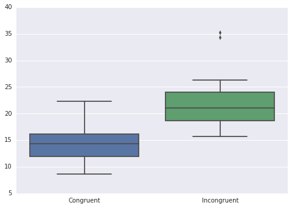

```python
sns.boxplot(stroop[['Congruent', 'Incongruent']])
```

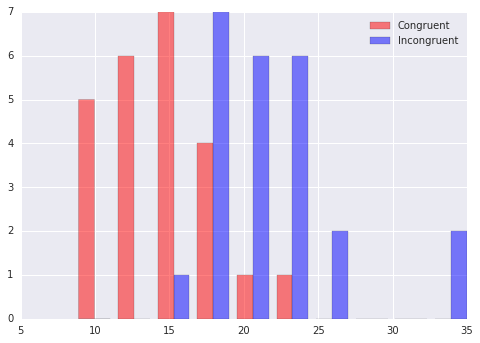

```python
plt.hist([stroop.Congruent, stroop.Incongruent], color = ['r', 'b'], label = ['Congruent', 'Incongruent'], alpha = 0.5)
plt.legend()
plt.show()
```

In the first plot we can clearly see that Congruent mean is less than Incongruent mean. We can clearly observe the outliers in Incongruent boxplot. In second plot also we can see this outliers. For congruent we can see the values starting from below 10. But for Incongruent the values are starting from 15 onwards which is greater than the mean of congruent. So there is an observable difference between the two means. Now we will do some statistical test to prove this.

### 5. Now, perform the statistical test and report your results. What is your confidence level and your critical statistic value? Do you reject the null hypothesis or fail to reject it? Come to a conclusion in terms of the experiment task. Did the results match up with your expectations?

We are taking 95% confidence level **T test results**:

1. t statistic = -8.020706944
2. Alpha value = 0.05
3. t citrical values for two tailed test at an alpha of 0.05 = (-2.069, +2.069)
4. Two tailed p-value = 0.000000041
5. Effect size measure(cohen's d) = -1.637219912901304
6. 95% confidence interval for mean population difference = (-10.01440277, -5.91518)

Yes, Based on these calculations I reject the null hypotheses. There is a significant difference between the mean values of time taken by participants to read Congruent and Incongruent words. Specifically, participants took significantly fewer time to read Congruent words than to read Incongruent words. The difference between these two word sets has causal effect on reading time.

When I took this test, I found that Incongruent words took much time to finish than Congruent words. Yes, the results did match up with my expectations.

### 6. Optional: What do you think is responsible for the effects observed? Can you think of an alternative or similar task that would result in a similar effect? Some research about the problem will be helpful for thinking about these two questions!

I suspect this is because of our brain structure. Our brain uses separate modules to do different tasks. When color and text is different, there is some lag in processing the information. Another similar task would be writing with hand other than what people normally use to write. Personally I took longer to write with left hand than right hand (I am a right handed person).

### References:

1. [Stroop Effect](https://www.rit.edu/cla/gssp400/sbackground.html)
2. [Hypotheses Testing](https://onlinecourses.science.psu.edu/statprogram/node/138)
3. Udacity Discussions
4. [Seaborn](http://stanford.edu/~mwaskom/software/seaborn/index.html)